# Predictions using the Weight Lifting Dataset

Jatin chawda

2/24/2020

# Summary

The data for this project come from this source: http://web.archive.org/web/20161224072740/http:/groupware.les.inf.puc-rio.br/har.

training data > https://d396qusza40orc.cloudfront.net/predmachlearn/pml-training.csv

testing data > https://d396qusza40orc.cloudfront.net/predmachlearn/pml-testing.csv Based on a dataset provide by HAR http://groupware.les.inf.puc-rio.br/har we will try to train a predictive model to predict what exercise was performed using a dataset with 159 features

We’ll take the following steps:

1. Process the data
2. Explore the data
3. Model selection
4. Test results

# Process the data

```r
trainRaw <- read.csv("data.csv")

testRaw <- read.csv("validation.csv")
```

# Explore the data

```r
dim(trainRaw)

dim(testRaw)

sum(complete.cases(trainRaw))
```

[output not shown]

We Have Seen Lots of NA Values Lets Remove those

```r
trainRaw <- trainRaw[, colSums(is.na(trainRaw)) == 0]
testRaw <- testRaw[, colSums(is.na(testRaw)) == 0]
```

Also remove all time related data, since we won’t use those Then convert all factors to integers

```r
classe <- trainRaw$classe
trainRemove <- grepl("^X|timestamp|window", names(trainRaw))
trainRaw <- trainRaw[, !trainRemove]
trainCleaned <- trainRaw[, sapply(trainRaw, is.numeric)]
trainCleaned$classe <- classe
testRemove <- grepl("^X|timestamp|window", names(testRaw))
testRaw <- testRaw[, !testRemove]
testCleaned <- testRaw[, sapply(testRaw, is.numeric)]
```

## Now We Will Do Some Expolatory Data Analysis

Since the test set provided is the the ultimate validation set, we will split the current training in a test and train set to work with.

```r
set.seed(22519)
inTrain <- createDataPartition(trainCleaned$classe, p=0.70, list=F)
trainData <- trainCleaned[inTrain, ]
testData <- trainCleaned[-inTrain, ]
```

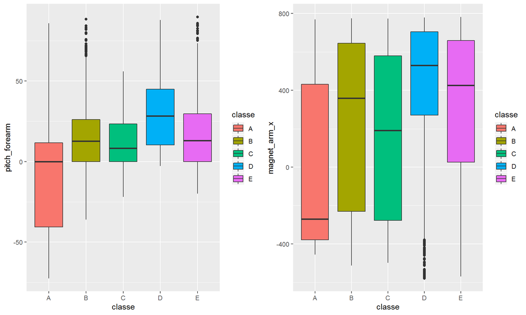

```r
library(Rmisc)
library(ggplot2)
p1 <- ggplot(trainData, aes(classe,pitch_forearm)) +
  geom_boxplot(aes(fill=classe))

p2 <- ggplot(trainData, aes(classe, magnet_arm_x)) +
  geom_boxplot(aes(fill=classe))

multiplot(p1,p2,cols=2)
```

Clearly there is no hard seperation of classes possible using only these ‘highly’ correlated features. Let’s train some models to get closer to a way of predicting these classe’s

# Model selection

Let’s identify variables with high correlations amongst each other in our set, so we can possibly exclude them from the pca or training.

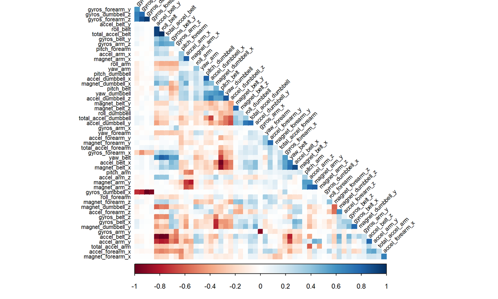

```r
corrPlot <- cor(trainData[, -length(names(trainData))])
corrplot(corrPlot, method="color", type="lower", order="hclust", tl.cex=0.70, tl.col="black", tl.srt = 45, diag = FALSE)
```

We see that there are some features that aree quite correlated with each other.

Now we’ll do some actual Random Forest training. We fit a predictive model for activity recognition using Random Forest algorithm because it automatically selects important variables and is robust to correlated covariates & outliers in general. We will use 5-fold cross validation when applying the algorithm.

```r
controlRf <- trainControl(method="cv", 5)
modelRf <- train(classe ~ ., data=trainData, method="rf", trControl=controlRf, ntree=250)
modelRf
```

```
## Random Forest
##
## 13737 samples
##    52 predictor
##     5 classes: 'A', 'B', 'C', 'D', 'E'
##
## No pre-processing
## Resampling: Cross-Validated (5 fold)
## Summary of sample sizes: 10988, 10989, 10989, 10991, 10991
## Resampling results across tuning parameters:
##
##   mtry  Accuracy   Kappa
##    2    0.9912654  0.9889499
##   27    0.9916291  0.9894104
##   52    0.9842766  0.9801110
##
## Accuracy was used to select the optimal model using the largest value.
## The final value used for the model was mtry = 27.
```

#Test results

we apply the model to the original testing data set downloaded from the data source. We remove the problem_id column first.

```r
result <- predict(modelRf, testCleaned[, -length(names(testCleaned))])
result
```

```
##  [1] B A B A A E D B A A B C B A E E A B B B
## Levels: A B C D E
```

## Appendix: Figures

1. Correlation Matrix Visualization

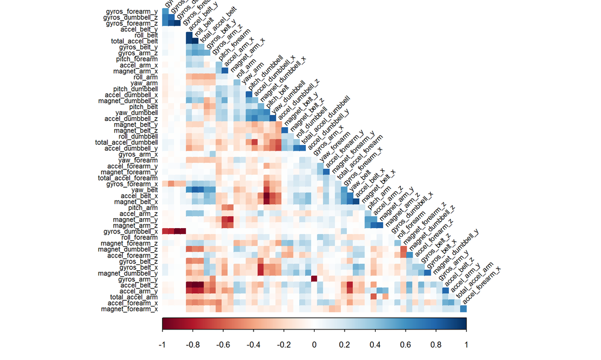

```r
corrPlot <- cor(trainData[, -length(names(trainData))])
corrplot(corrPlot, method="color", type="lower", order="hclust", tl.cex=0.70, tl.col="black", tl.srt = 45, diag = FALSE)
```

2. Decision Tree Visualization

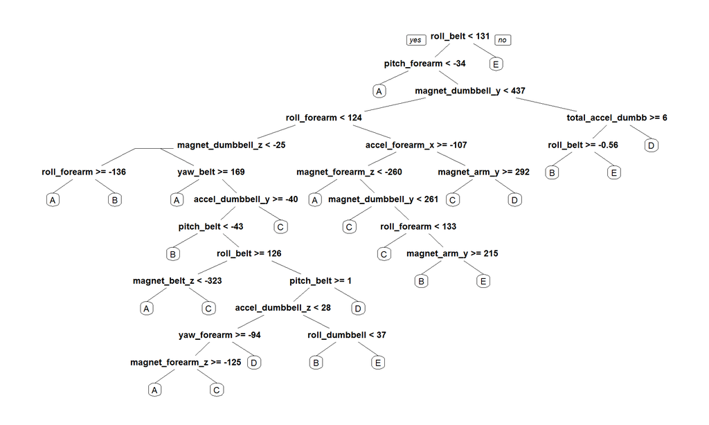

```r
treeModel <- rpart(classe ~ ., data=trainData, method="class")
prp(treeModel)
```